# 热工基础 · 第 6 讲：对流换热

刘训臣

山东科技大学 机械电子工程学院

# 第〇部分 · 课程介绍与本讲定位

- 教学内容与主线、7 次课进度表
- 本讲定位：第 5 讲给了导热，本讲做对流换热
- 对流换热机理与牛顿冷却公式
- 边界层、微分方程组与影响因素

## 第 6 讲：教学内容与主线

> **两个课时、一条主线：从牛顿冷却到实验关联式——核心任务是求 $h$。**

**课时 1 · 对流换热机理与微分方程组**

- 对流换热 = 热对流 + 壁面导热；牛顿冷却公式 $q=h\Delta t$（$h$ 是定义式，不是定律）
- 流动边界层与热边界层：层流、湍流；壁面换热形态（单相 / 沸腾 / 凝结）
- 连续性、动量（N–S）、能量方程组 + 对流换热过程微分方程

> 一句话：**机理给出方程，量纲分析给出框架，实验给出系数——三者合起来才能算出 $h$。**

## 课时 2：本课时内容

- 讲义 dimensionless number 段：惯性力/黏性力分解、Buckingham Π、单位表与无量纲数表
- 相似原理：同名准则数相等 ⇒ 模型实验可代表实物
- 受迫对流（Dittus–Boelter）、外部绕流（横掠圆管脱体）、自然对流（$Nu=C\,Ra^n$）
- 凝结（Nusselt 膜状凝结）与沸腾（罗森诺、临界热流密度）的计算式

> 一句话：**本课时把”求 $h$“变成”查关联式 + 核验适用条件”。**

## 教学进度 · 7 次课全览

| 次 | 教材章 | 主题 | 课时 1 / 课时 2 |
| --- | --- | --- | --- |
| 1 | 第 1、2 章 | 基本概念、统计热力学与热力学基本定律 | 基本概念与统计力学图像 / 热力学基本定律与函数 |
| 2 | 第 3 章 | 理想气体与热力过程 | 理想气体（状态方程、内能、熵） / 热力过程与 Carnot 循环 |
| 3 | 第 4、5 章 | 气体混合、水蒸汽、湿空气与气体流动 | 气体混合物、水蒸汽与湿空气 / 气体流动与喷管 |
| 4 | 第 6、7 章 | 压气机与动力循环、制冷循环 | 压气机与气体动力循环 / 蒸汽动力循环与制冷循环 |
| 5 | 第 8、9 章 | 导热 | 三种传热方式与 Fourier 导热定律 / 稳态导热与热阻分析 |
| **6** | **第 10 章** | **对流换热** | **对流机理与边界层、准则数 / 准则关联式及其应用** |
| 7 | 第 11、12 章 | 热辐射、换热器与总复习 | 热辐射基本定律与辐射换热计算 / 换热器与全课程总复习 |

## 本讲在课程中的位置（一）

**第 5 讲已经给了什么**：

- 三种基本传热方式：导热、对流、热辐射（各自的机理）
- 导热：Fourier 定律 $q=-\lambda\nabla T$；热扩散方程 $\partial T/\partial t=a\nabla^2T$；$a=\lambda/(\rho c)$
- 三类边界条件：定温 / 定热流 / **对流边界**（第三类：$-\lambda\frac{\partial T}{\partial n}|_w=h(T_w-T_\infty)$）

**本讲补什么**：

- 第 5 讲只把 $h$ 当作”给定的边界条件参数”——本讲回答：**$h$ 从哪来、怎么求**
- $h$ 依赖流动与几何，不能从物性表查 → 靠**机理方程 + 量纲分析 + 实验关联式**

## 本讲定位（二）：推导留给 AI

**推导留给 AI**：① 让他比较”导热系数 λ”与”表面传热系数 h”：单位、是否物性、由什么决定；② 问：“为什么对流换热的公式 $q=h\Delta t$ 叫’牛顿冷却公式’却不算基本定律？”（提示：它只是把复杂机理打包进 h 的定义式）；③ 让他举一个”自然对流”和”强制对流”各一例的工程场景，并说明判断依据。

# 第一部分 · 对流换热机理与牛顿冷却

- 对流换热的物理图像：热对流 + 贴壁导热
- 牛顿冷却公式与表面传热系数 $h$
- 流动边界层与热边界层、层流与湍流
- 壁面换热形态：单相、沸腾与凝结

## 对流换热的物理图像

- **热对流**：流体宏观运动引起的热量传递（三种基本传热方式之一）
- **对流换热**：流体与固体壁面之间的换热 = 热对流 + 壁面附近导热
- 紧贴壁面处流体速度为零，热量只能靠**导热**穿过极薄的流体层，再被主流带走

## 牛顿冷却公式

$$q = h(T_w - T_\infty), \qquad Q = hA\Delta t$$

- $h$：**对流换热系数（表面传热系数）**，单位 $\text{W}/(\text{m}^2\cdot\text{K})$
- $h$ **不是物性**，而是流动状态与几何形状的函数
- 牛顿冷却公式不是定律，只是 $h$ 的定义式，难点全在求 $h$

## 表面传热系数 h 的量级

| 换热形态 | $h$ 量级 $\text{W}/(\text{m}^2\cdot\text{K})$ |
| --- | --- |
| 自然对流（空气） | 2–25 |
| 强制对流（气体） | 25–250 |
| 强制对流（液体） | 50–20 000 |
| 沸腾 / 凝结 | 2 500–100 000 |

## 对流换热过程微分方程

壁面处对流热流 = 紧贴壁面流体的导热热流：

$$q = h(t_w - t_\infty) = -\lambda\left.\frac{\partial t}{\partial y}\right|_{y=0} \quad\Rightarrow\quad h = -\frac{\lambda}{t_w - t_\infty}\left.\frac{\partial t}{\partial y}\right|_{y=0}$$

## 流动边界层与热边界层

- **速度边界层**：壁面附近流速由 0 增至主流速度 $u_\infty$ 的薄层，厚度 $\delta$（定义到 $0.99u_\infty$）
- **热边界层**：壁面附近温度由 $t_w$ 变到 $t_\infty$ 的薄层，厚度 $\delta_t$（定义到 $0.99(t_w-t_\infty)$）
- **边界层越薄，壁面法向温度梯度越大，$h$ 越大**
- $\delta$ 与 $\delta_t$ 的相对大小由 $Pr$ 决定：$Pr\approx1$ 两者接近；$Pr>1$（油类）$\delta_t<\delta$；$Pr<1$（液态金属）$\delta_t>\delta$

## 层流与湍流边界层

- **层流**：流体分层流动、无横向掺混，壁面法向传热只靠分子导热 → $h$ 较小
- **湍流**：主流强烈掺混，但贴壁仍有一层**层流底层**（导热控制）
- 湍流边界层的层流底层比层流边界层薄得多 → 壁面温度梯度大 → $h$ 显著增大
- 判据：$Re$ 超过临界值（平板约 $5\times10^5$、管内约 $2300$）转湍流

## 壁面换热的形态：单相与相变

- **单相对流**：自然对流（浮升力驱动）/ 强制对流（外力驱动），$h$ 几十~几千 $\text{W/(m}^2\cdot\text{K)}$
- **相变换热**：沸腾（液→气）、凝结（气→液），潜热大 + 气泡/液滴扰动强 → $h$ 可达上万
- 凝结形态：**膜状凝结**（液膜覆盖壁面，成为主要热阻）vs **珠状凝结**（液珠滚落、潜热直达壁面，$h$ 高约一个量级）
- 沸腾形态：随壁面过热度依次经历四个阶段（下页）

## 大容器沸腾的四阶段

1. **自然对流**：过热度小，无气泡，热量靠单相自然对流
2. **核态沸腾**：气泡在核化点生成、长大、脱离，扰动极强，$h$ 最大——**工业工作区**
3. **过渡沸腾**：气泡来不及脱离、连成汽膜，$h$ 骤降（不稳定）
4. **膜态沸腾**：稳定汽膜把壁面与液体隔开（Leidenfrost 现象），$h$ 最小

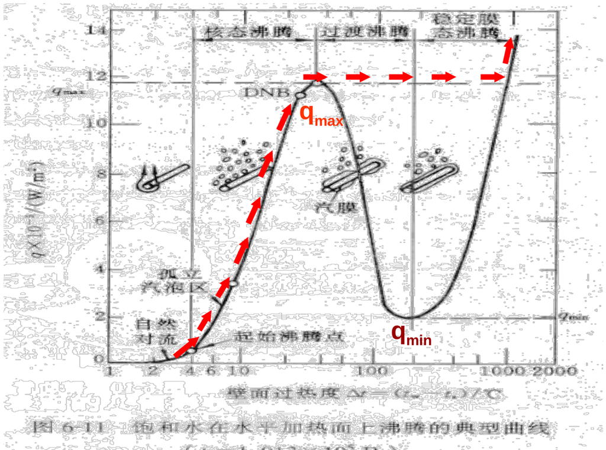

大容器饱和沸腾曲线

Nukiyama 沸腾曲线：热流密度 $q$ 随过热度先升、后降、再升；核态终点对应**临界热流密度 $q_\text{max}$（烧毁点）**。

## 凝结换热：膜状与珠状

**膜状凝结**：凝结液能很好湿润壁面、均匀铺展成膜——液膜成为**主要热阻**（潜热须穿过液膜才传到壁面）。

**珠状凝结**：凝结液不能湿润壁面，形成小液珠滚落——潜热**不穿过液膜**直达壁面 ⇒ $h$ 比膜状**高约一个量级**。

- 膜状：$h$ 较小但稳定、可持久——**工业设计按膜状保守计算**
- 珠状：$h$ 大但难持久（表面很快被润湿），工程上靠表面处理（憎水涂层）局部实现

## 煮稀饭的传热学：粘度如何改变一切

- 淀粉糊化使粥**粘度剧增**：$Ra = \dfrac{g\beta\Delta T\,L^3}{\nu a}$ 中 $\nu$ 增大 → 自然对流被抑制 → 热量只能靠**导热**穿过粘稠层 → **锅底过热、糊锅**
- 粘稠液中的气泡被”淀粉皮”包住、不易破裂：小泡合并成大泡、上升慢，膨胀溢出 → **扑锅**；水的粘度低，气泡小、上升快、到水面即破，不扑锅
- 同样的锅烧水：$\nu$ 小 → 自然对流强 → 底部热量被及时带走，不糊
- 极热的锅面上水滴跳舞不润湿——**膜态沸腾 / Leidenfrost 现象**

## 思考与提问 · 对流机理

1. 牛顿冷却公式把一切复杂性”打包”进 $h$。请找出一个 $h$ 会随时间显著变化的场景（提示：沸腾的不同阶段），说明此时”用牛顿冷却公式算稳态换热”还成立吗？
2. 为什么珠状凝结的 $h$ 大却无法在工业中普遍使用？请让 AI 查证近年”超疏水表面实现持久珠状凝结”的进展，并判断其工程可行性。
3. 风扇让人凉快，究竟是对流换热、蒸发换热、还是两者？请用本讲的 h 量级表估算：汗液蒸发和空气对流哪个贡献大？

# 第二部分 · 对流换热微分方程组与边界层

- 连续性、动量（N–S）、能量方程组
- 对流换热过程微分方程：$h$ 与壁面温度梯度的联系
- 边界层概念与数量级分析
- 影响对流换热的因素

## 对流换热的影响因素

- 流动起因：受迫 / 自然
- 有无相变：凝结、沸腾显著强化换热
- 流动状态：层流 / 湍流
- 换热表面几何：形状、尺寸、位置
- 流体物性：$\rho,\ c_p,\ \lambda,\ \nu,\ \ldots$

## 对流换热微分方程组

描述速度场与温度场的方程组（不可压缩、常物性）：

1. 连续性方程：$\nabla\cdot\vec v = 0$
2. 动量方程（Navier–Stokes）：$\rho\dfrac{D\vec v}{Dt} = -\nabla p + \mu\nabla^2\vec v + \rho\vec g$
3. 能量方程：$\rho c_p\dfrac{DT}{Dt} = \lambda\nabla^2 T$
4. 对流换热过程微分方程：$h = -\dfrac{\lambda}{t_w-t_\infty}\left.\dfrac{\partial t}{\partial y}\right|_{y=0}$

## 边界层概念

- **速度边界层**：壁面附近流速由 0 增至主流速度 $u_\infty$ 的薄层，厚度 $\delta$
- **热边界层**：壁面附近温度由 $t_w$ 变到 $t_\infty$ 的薄层，厚度 $\delta_t$
- 层流边界层：$h$ 较小；湍流边界层：$h$ 明显增大
- 边界层越薄，壁面法向温度梯度越大，$h$ 越大

## 边界层的数量级分析

对平壁边界层内动量方程各项做数量级估计（$x$ 方向对流项 $\sim \rho u_\infty^2/x$，黏性项 $\sim \mu u_\infty/\delta^2$）：

$$\frac{\delta}{x}\sim\frac{1}{\sqrt{Re_x}},\qquad Re_x=\frac{u_\infty x}{\nu}$$

- 层流边界层厚度随 $x$ 增大而增厚（$\delta\propto\sqrt{x}$）；$Re_x$ 大 ⇒ 相对厚度薄
- 热边界层与速度边界层的相对厚度：

$$\frac{\delta_t}{\delta}\sim Pr^{-1/3}$$

- 由此可估计局部换热系数：$h_x=\dfrac{\lambda}{\delta_t}\sim \dfrac{\lambda}{x}\,Re_x^{1/2}Pr^{1/3}$

# 第三部分 · 量纲分析与相似准则

- Buckingham Π 定理：$n$ 个量、$k$ 个量纲 ⇒ $n-k$ 个 $\pi$ 数
- 动量方程与能量方程各项分解（讲义 dimensionless number 段）
- 单位表与无量纲数表（讲义原表完全写入）
- $Re$、$Nu$、$Pr$、$Gr$、$Ra$ 的物理意义与相似原理

## Buckingham Π 定理

**讲义原文表述**：如果一个物理问题涉及 $n$ 个物理量（变量），而这些物理量依赖于 $k$ 个基本量纲（如质量 $M$、长度 $L$、时间 $T$），那么描述这个问题的物理定律就可以用 $(n-k)$ 个独立的无量纲数（$\pi$ 数）来表示：

$$F(\pi_1,\pi_2,\dots,\pi_{n-k})=0$$

**例子（管内强制对流求 $h$）**：涉及 $h,u,\rho,\mu,\lambda,c_p,d$ 共 $n=7$ 个量、基本量纲 $M,L,T,\Theta$ 共 $k=4$ 个 ⇒ $7-4=3$ 个独立 $\pi$ 数：$Nu=f(Re,Pr)$——**7 维实验压到 3 维**。

## 动量方程：惯性力与黏性力的分解

**讲义原式**（三维流场动量方程，逐项归类）：

$$\overbrace{\underbrace{\rho\frac{\partial u}{\partial t}}_{\text{瞬变项}}+\underbrace{\rho u\frac{\partial u}{\partial x}+\rho v\frac{\partial u}{\partial y}+\rho w\frac{\partial u}{\partial z}}_{\text{对流项}}}^{\text{惯性力}}=\overbrace{\frac{\partial p}{\partial x}}^{\text{压力}}+\overbrace{\frac{\partial}{\partial x}\Big(\nu\rho\frac{\partial u}{\partial x}\Big)+\frac{\partial}{\partial y}\Big(\nu\rho\frac{\partial u}{\partial y}\Big)+\frac{\partial}{\partial z}\Big(\nu\rho\frac{\partial u}{\partial z}\Big)}^{\text{黏性力}}+\overbrace{\rho g_x}^{\text{重力}}$$

- 惯性力 = 瞬变项（非稳态）+ 对流项（迁移加速度）
- 每一项都对应一个准则数：瞬变/对流 → $Sr$、惯性/黏性 → $Re$、压力/惯性 → $Eu$、惯性/重力 → $Fr$

## 能量方程：携带热与各项

**讲义原式**（能量方程，逐项归类）：

$$\rho T\frac{ds}{dt}=\overbrace{\rho\frac{dh}{dt}-\frac{dp}{dt}}^{\text{携带热}}=\overbrace{\rho q}^{\text{热源}}+\overbrace{\nabla\cdot(\lambda\nabla T)}^{\text{传导热}}+\overbrace{2\mu S^2-\tfrac23\mu(\nabla\cdot v)^2}^{\text{黏性热}}$$

- 携带热（焓的随体变化 − 压力功）= 热源 + 传导热 + **黏性耗散热**
- 高速流动时黏性耗散热不可忽略（气动加热的机理之一）
- 携带热/传导热 ⇒ $Pe$；对流热损失/传导热 ⇒ $Nu$

## 动量方程和能量方程中的单位（讲义原表）

| 项 | 单位（讲义原表） |
| --- | --- |
| 瞬变项 | $\rho v t^{-1}$ |
| 对流项 | $\rho v^2 l^{-1}$ |
| 黏性力 | $\rho\nu v l^{-2}$（讲义原写 $\rho\nu t^{-1}$，笔误已订正） |
| 表面力 | $p\,l^{-1}$ |
| 重力 | $\rho g$ |
| 携带热 | $\rho c_p T v l^{-1}$ |
| 传导热 | $\lambda T l^{-2}$ |
| 对流热损失 | $h\,l\,T$ |

> 说明：讲义 Table「动量方程和能量方程中的单位」中”黏性力”一行原写 $\rho\nu t^{-1}$，按量纲应为 $\rho\nu v l^{-2}$（与惯性力/黏性力=Re 的结论一致），已在表中订正；其余各行照录。

## 一系列无量纲数（讲义原表）

| 比值 | 无量纲数 | 名称 |
| --- | --- | --- |
| 瞬变项/对流项 | $l/(vt)$ | $St$ |
| 黏性力/瞬变项 | $\mu/(\rho l v)$ | $N^2_s$ |
| 惯性力/黏性力 | $\rho v l/\mu$ | $Re$ |
| 惯性力/重力 | $v^2/(g l)$ | $Fr$ |
| 表面力/惯性力 | $p/(\rho v^2)$ | $Eu$ |
| 惯性力/弹性力（$\Delta p=c^2\Delta\rho\,l^{-1}$） | $v^2/c^2$ | $Ma^2$ |
| 携带热/传导热 | $Re\cdot\mu c_p/\lambda$ | $Re\cdot Pr=Pe$ |
| 对流热损失/传导热 | $hl/\lambda$ | $Nu$ |

> 说明：讲义表「动量方程和能量方程中的无量纲数」中”瞬变项/对流项”一行原写 $l/v\,t^{-1}$，按量纲应为 $l/(vt)$（Strouhal 数），已订正；“黏性力/瞬变项”行照录讲义原值 $\mu/\rho l v$（按订正后的黏性力量纲，黏性力/瞬变项应为 $\nu t/l^2$，讲义原值实为黏性力/对流项），此处照录并注明。

## 动量方程的无量纲化

用特征长度、特征时间、特征速度、无穷远静压对动量方程无量纲化（讲义原式）：

$$Sr\frac{\partial v'}{\partial\tau}+(v'\cdot\nabla)v'=-Eu\,\nabla p'+\frac{1}{Re}\nabla^2 v'$$

- 各项系数 $Sr$、$Eu$、$1/Re$ 就是对应的无量纲数
- 带撇量为无量纲量（$v'=v/u_\infty$、$p'=p/p_\infty$、$\tau=t/t_0$）

## 核心无量纲数（必记）

| 无量纲数 | 定义 | 物理意义 |
| --- | --- | --- |
| Reynolds $Re$ | $\dfrac{\rho v l}{\mu}=\dfrac{vl}{\nu}$ | 惯性力 / 黏性力 |
| Nusselt $Nu$ | $\dfrac{hl}{\lambda}$ | 对流换热 / 同层导热 |
| Prandtl $Pr$ | $\dfrac{\nu}{a}=\dfrac{\mu c_p}{\lambda}$ | 动量扩散 / 热扩散 |
| Grashof $Gr$ | $\dfrac{g\beta\Delta t\, l^3}{\nu^2}$ | 浮升力 / 黏性力 |
| Rayleigh $Ra$ | $Gr\cdot Pr=\dfrac{g\beta\Delta t\, l^3}{\nu a}$ | 自然对流控制参数 |

## 其他无量纲数

| 无量纲数 | 定义 | 物理意义 |
| --- | --- | --- |
| Strouhal $Sr$ | $\dfrac{l}{vt}$ | 瞬变项 / 对流项 |
| Froude $Fr$ | $\dfrac{v^2}{gl}$ | 惯性力 / 重力 |
| Euler $Eu$ | $\dfrac{p}{\rho v^2}$ | 表面力 / 惯性力 |
| Mach $Ma$ | $\dfrac{v}{c}$ | 动能 / 内能 |
| Péclet $Pe$ | $Re\cdot Pr$ | 携带热 / 传导热 |
| Stanton $St$ | $\dfrac{Nu}{Re\,Pr}=\dfrac{h}{\rho c_p v}$ | 对流热 / 携带热 |

## 相似原理与模型实验

- 两个现象**几何相似**且**同名无量纲数相等**，则物理相似（对应量成比例）
- 实验数据可整理成无量纲关联式，推广到同类问题
- 保证模型实验与实物相似 = 保证 Re、Pr 等准则数相等
- 工程上无法同时满足所有准则数时，抓主导准则（强制对流抓 $Re$，自然对流抓 $Gr/Ra$）

## 思考与提问 · 量纲分析

1. Π 定理说 $n$ 个量、$k$ 个量纲给出 $n-k$ 个 $\pi$ 数。请找一个”看起来无量纲数很多、其实只有少数独立”的例子，并说明哪些是重复的（提示：$Pe=Re\cdot Pr$、$Ra=Gr\cdot Pr$、$St=Nu/(Re\,Pr)$）。
2. 风洞实验用 1/10 缩比模型模拟实物。若想保持 $Re$ 相等，模型风速要变成多少倍？由此说明”完全相似”在工程上为什么常常做不到（提示：同时满足 $Re$ 与 $Ma$ 的困难）。
3. 让 AI 查证：Buckingham Π 定理为什么叫”Π 定理”？它与瑞利（Rayleigh）量纲法是什么关系？

# 第四部分 · 实验关联式

- 管内受迫对流：Dittus–Boelter 与适用条件
- 外部绕流：流体横掠圆管的脱体现象
- 自然对流关联式 $Nu=C\,Ra^n$ 与查表
- 凝结（Nusselt 膜状）与沸腾（罗森诺、临界热流密度）计算

## 受迫对流关联式：一般形式

$$Nu = C\,Re^m Pr^n$$

管内旺盛湍流（Dittus–Boelter）：

$$Nu = 0.023\,Re^{0.8}Pr^{n},\qquad \begin{cases} n=0.4 & \text{流体被加热}\\ n=0.3 & \text{流体被冷却} \end{cases}$$

## Dittus–Boelter 的适用条件

| 条件 | 范围 |
| --- | --- |
| 流动状态 | 旺盛湍流 $Re=10^4\sim1.2\times10^5$ |
| $Pr$ | $0.7\sim120$ |
| 管长 | 长直管 $l/d\ge60$（充分发展段） |
| 温差 | 流体与壁面温差中等（温差大时物性变化明显） |
| 定性温度 | 进出口平均温度 $t_f=(t_f'+t_f'')/2$ |
| 特征长度 | 管内径 $d$ |

- $n$ 的取法：流体**被加热** $n=0.4$、**被冷却** $n=0.3$（壁面温度对物性的影响方向不同）
- 超范围修正：短管（入口段强化）乘修正系数、大温差乘物性修正系数（查教材）

## 流体横掠圆管：脱体与旋涡

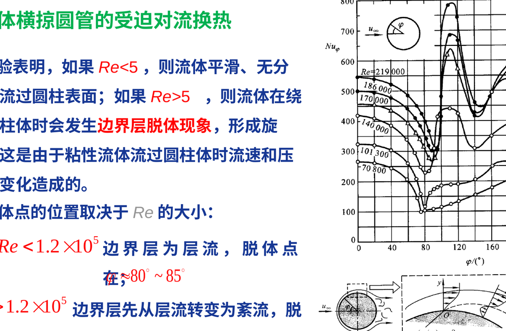

流体横掠圆管

- $Re<5$：流体平滑、无分离地流过圆柱表面
- $Re>5$：**边界层脱体**，在圆柱后部形成旋涡（尾流）
- 脱体点位置取决于 $Re$：$Re$ 增大，脱体点后移
- 关联式：$Nu=C\,Re^n Pr^{1/3}$（常数 $C,n$ 按 $Re$ 范围查表，教材第 10 章）

## 自然对流关联式

自然对流由温度差引起的浮升力驱动，准则方程：

$$Nu = C(Gr\cdot Pr)^n = C\,Ra^n$$

| 换热面形状与位置 | $Ra$ 范围 | $C$ | $n$ |
| --- | --- | --- | --- |
| 竖壁/竖圆柱（层流） | $10^4\sim10^9$ | 0.59 | 1/4 |
| 竖壁/竖圆柱（湍流） | $10^9\sim10^{13}$ | 0.10 | 1/3 |
| 水平圆柱（层流） | $10^4\sim10^9$ | 0.53 | 1/4 |

- 特征数：$Gr$（浮升力/黏性力）、$Ra=Gr\,Pr$；层流/湍流判据即 $Ra$ 临界值
- 特征长度：竖壁取高度，横圆柱取外径
- 定性温度：$t_m=(t_w+t_\infty)/2$；对理想气体可用 $Gr'=Gr\,\beta T$ 形式修正

## 大空间与有限空间自然对流

- **大空间**：流体的冷却和加热过程互不影响、边界层不受干扰（如单块竖壁在大房间中）
- **有限空间**：边界层相互干扰（如夹层、封闭腔）
- 判定（教材）：两热竖壁底部封闭时，只要**夹层足够厚**；底部开口时，只要**开口足够大**——壁面换热即可按大空间处理（“大空间的相对性”）
- 工程处理：有限空间换热按”导热 + 对流”的等效导热系数法（$Nu=f(Ra,\text{几何})$）

## 凝结换热：Nusselt 竖壁膜状凝结

**Nusselt 简化假设**（教材 6 条）：① 常物性纯净蒸汽静止；② 忽略液膜惯性力与汽液界面黏性阻力；③ 界面无温差（液膜温度 = 饱和温度，忽略过冷）；④ 膜内温度线性分布（热量只靠导热）；⑤ 忽略蒸汽密度；⑥ 液膜表面平整无波动。

**结果**（层流膜状凝结，竖壁高 $l$）：

$$\bar h=0.943\left[\frac{g\,r\,\rho_l^2\,\lambda_l^3}{\mu_l\,l\,\Delta t}\right]^{1/4},\qquad \Delta t=t_s-t_w$$

- 定性温度 $t_m=(t_s+t_w)/2$；$r$ 按饱和温度 $t_s$ 取
- 液膜表面波动使实验值比理论高约 20% ⇒ 修正后系数 $0.943\to1.13$

## 凝结换热：横管、球与影响因素

**水平圆管与球（层流膜状凝结）**：

$$\bar h_{\text{横管}}=0.725\left[\frac{g r \rho_l^2\lambda_l^3}{\mu_l d \Delta t}\right]^{1/4},\qquad \bar h_{\text{球}}=0.826\left[\cdots\right]^{1/4}$$

## 沸腾换热计算：罗森诺与临界热流密度

**牛顿冷却公式仍然适用**：$q=h\,\Delta t$，但 $h$ 需用沸腾关联式。

**罗森诺公式**（适用于各种液体，大容器饱和沸腾）：

$$q=\mu_l r\left[\frac{g(\rho_l-\rho_v)}{\sigma}\right]^{1/2}\left[\frac{c_{pl}\,\Delta t}{C_{wl}\,r\,Pr_l^n}\right]^{3}$$

- $C_{wl}$：壁面-液体组合常数（水-铜约 0.013 等，查表）；$n=1.0$（水）/ $1.7$（其他液体）
- 另有适用于水的**米海耶夫计算式**（工程查教材）

**临界热流密度**（大容器沸腾，半经验公式）：

$$q_{\max}\approx0.131\,r\,\rho_v^{1/2}\left[\sigma g(\rho_l-\rho_v)\right]^{1/4}$$

- $q_{\max}$ 即**烧毁点**：核态沸腾的终点，热流密度可控的场合（电加热）越过它壁温骤升、设备烧毁

## 思考与提问 · 关联式

1. Dittus–Boelter 公式里”加热 n=0.4、冷却 n=0.3”。请从物性随温度变化的方向解释这个差别（提示：水的 μ 随 T 升高而减小，近壁层变薄），并让 AI 查证你的解释。
2. 自然对流里 $\bar h\propto(\Delta t)^{1/4}$（层流），而凝结里 $\bar h\propto(\Delta t)^{-1/4}$。请解释为什么两者对温差的依赖**方向相反**（提示：一个靠浮升驱动增强、一个靠液膜增厚抑制）。
3. 让 AI 给出”不凝气体使凝结 h 下降”的定量例子（如凝汽器漏入 1% 空气 h 降多少），并判断它给的数据是否可信。

# 第五部分 · 例题与真题

- 真题：对流换热与热对流、凝结与沸腾、微分方程、表达式
- 算例 1：Dittus–Boelter 管内水换热
- 算例 2：自然对流竖壁散热
- 算例 3：横管膜状凝结

## 真题 5：对流换热与热对流

**简答**：简述对流换热与热对流的区别。（2024—2025 春 A 卷）

**参考答案**：

- **热对流**：流体宏观运动引起的热量传递（三种基本传热方式之一）
- **对流换热**：流体与固体壁面之间的换热，包含热对流与导热，用牛顿冷却公式 $q = h\Delta T$ 描述

## 真题 6：凝结与沸腾

**判断/简答**：

1. 相同条件下，膜状凝结换热的表面传热系数高于珠状凝结。（2025—2026 学年 A 卷判断）→ **错误**，珠状凝结更高
2. 大容器沸腾随过热度增大依次出现的阶段？（A 卷简答）→ **自然对流、核态沸腾、过渡沸腾、膜态沸腾**

## 真题 7：对流换热过程微分方程

**简答**：写出对流换热过程微分方程。（2025—2026 学年 A 卷 / 2026 春 A1 卷）

**参考答案**：

$$q = h(t_w - t_\infty) = -\lambda\left.\frac{\partial t}{\partial y}\right|_{y=0}, \qquad h = -\frac{\lambda}{t_w-t_\infty}\left.\frac{\partial t}{\partial y}\right|_{y=0}$$

- 物理意义：壁面处对流热流等于紧贴壁面流体的导热热流

## 真题 8：对流换热表达式

**简答**：写出对流换热的表达式，并解释每一部分的物理意义。（2024—2025 春 B 卷）

**参考答案**：

$$Q = hA\Delta t \qquad \text{或}\qquad q = h\Delta t$$

- $Q$（$q$）：对流换热量（热流密度）；$h$：表面传热系数
- $A$：换热面积；$\Delta t$：壁面与流体的温差

## 算例 1：Dittus–Boelter 管内水换热

**题**：水以 $v=1.5$ m/s 流过内径 $d=20$ mm、长 $2$ m 的管内被加热（$t_f=30$ ℃ 水，$\nu=0.805\times10^{-6}$ m²/s、$\lambda=0.618$ W/(m·K)、$Pr=5.42$），壁温与水温差 $30$ K。求 $h$ 与换热量。

**解（标准动作四步）**：

1. 核验适用范围：$Re=\dfrac{vd}{\nu}=\dfrac{1.5\times0.02}{0.805\times10^{-6}}=3.73\times10^4\in[10^4,1.2\times10^5]$ ✓；$l/d=100\ge60$ ✓；$Pr=5.42\in[0.7,120]$ ✓
2. 加热 → $n=0.4$：$Nu=0.023\,Re^{0.8}Pr^{0.4}=0.023\times(3.73\times10^4)^{0.8}\times5.42^{0.4}=205$
3. $h=\dfrac{Nu\,\lambda}{d}=\dfrac{205\times0.618}{0.02}=6344\ \text{W/(m}^2\cdot\text{K)}$
4. $Q=hA\Delta t=6344\times\pi\times0.02\times2\times30=23.9\ \text{kW}$

## 算例 2：自然对流竖壁散热

**题**：高 $0.5$ m、宽 $1$ m 的竖直壁面温度 $50$ ℃，空气 $30$ ℃（$t_m=40$ ℃：$\nu=16.0\times10^{-6}$ m²/s、$\lambda=0.0267$ W/(m·K)、$Pr=0.701$）。求 $h$ 与散热量。

## 算例 3：横管膜状凝结

**题**：100 ℃ 饱和水蒸气在直径 $20$ mm 的水平圆管外凝结，管壁 80 ℃（膜温 90 ℃：$\rho_l=965$ kg/m³、$\lambda_l=0.675$ W/(m·K)、$\mu_l=3.15\times10^{-4}$ Pa·s；$r=2257$ kJ/kg）。求 1 m 长横管的 $\bar h$ 与凝结放热量。

**解**：

$$\bar h=0.725\left[\frac{g r\rho_l^2\lambda_l^3}{\mu_l d\Delta t}\right]^{1/4}=0.725\left[\frac{9.81\times2257\times10^3\times965^2\times0.675^3}{3.15\times10^{-4}\times0.02\times20}\right]^{1/4}=10\,861\ \text{W/(m}^2\cdot\text{K)}$$

$$Q=\bar h\,(\pi dL)\Delta t=10\,861\times\pi\times0.02\times1\times20=13.6\ \text{kW}$$

- 对照：同条件下竖壁（系数 0.943）的 $\bar h\approx5310$ W/(m²·K)——长竖壁液膜更厚、$\bar h$ 更低
- 凝结换热 $h\sim10^4$ 量级，远大于单相气体对流——相变强化的实例

# 第六部分 · 思考题、小结与作业

- 作业：计算题 4 道 + 思考题 3 道
- 推导作业：讲义单位表与无量纲数表逐项核对
- 本讲小结：机理 → 方程 → 量纲分析 → 关联式
- 下讲预告：热辐射、换热器与总复习

## 作业（本讲）

**计算题（4 题）**

1. **Dittus–Boelter**：30 ℃ 水以 $v=2.0$ m/s 流过内径 $25$ mm 的长管被冷却（壁温 10 ℃；$t_f=30$ ℃ 物性同算例 1），求 $h$。先核验 Re、Pr 范围，冷却取 $n=0.3$。
2. **自然对流**：长 $3$ m 的水平圆柱（外径 $0.1$ m）表面 60 ℃，环境空气 20 ℃（$t_m=40$ ℃ 物性同算例 2），用 $C=0.53,\ n=1/4$ 求单位长度的散热量。
3. **膜状凝结**：100 ℃ 饱和水蒸气在 80 ℃ 竖壁（高 1 m）上膜状凝结，用 Nusselt 公式（系数 0.943）求 $\bar h$ 与总放热量，并说明若计入液膜波动修正（×1.2）结果变化多少。
4. **临界热流密度**：用 Zuber 公式估算 $p=0.1$ MPa 水大容器沸腾的 $q_{\max}$（$\rho_v=0.598$ kg/m³、$\rho_l=958$ kg/m³、$\sigma=0.0589$ N/m、$r=2257$ kJ/kg），并说明这个数对电加热器的安全含义。

## 作业（本讲·续）：思考题与阅读

**思考题（3 题）**

5. 为什么横掠圆管的换热系数沿周向不均匀（前驻点最强、后部因脱体而复杂）？画出示意并解释。
6. 说明”相似原理”为什么能指导模型实验：风洞 1/10 缩比模型若保持 Re 相等，风速要怎么变？为什么同时保持 Ma 相等就做不到？
7. 用本讲的量级表解释：为什么散热器（翅片）都加在气体侧而不是液体侧？

> **推导作业**：各页”推导留给 AI”按当次讲到的部分布置；讲义 dimensionless number 段的表逐项核对一遍（单位表 8 行、无量纲数表 8 行的比值）。

**阅读**：教材第 10 章；讲义 lec_5.tex 第 167–233 行；《传热学》（陶文铨）第 5、6 章相应部分。

## 本讲小结

**课时 1 · 机理与方程**

**课时 2 · 量纲分析与关联式**

- Π 定理：$n$ 个量、$k$ 个量纲 ⇒ $n-k$ 个 $\pi$ 数（7 维 → 3 维）
- $Re$（惯性/黏性）、$Nu$（对流热/导热）、$Pr$（动量/热扩散）、$Gr,Ra$（浮升驱动）
- 相似原理：同名准则数相等 ⇒ 模型实验代表实物
- 关联式：$Nu=0.023Re^{0.8}Pr^n$（管内）、$Nu=C\,Ra^n$（自然）、Nusselt 凝结、罗森诺沸腾——**用前必核适用条件**

## 下讲预告

**第 7 次课 · 热辐射、换热器与总复习**

- 热辐射：黑体辐射三大定律（Planck 谱分布、Wien 位移、Stefan–Boltzmann 四次方）、发射率与角系数、两表面辐射换热
- 换热器：复合换热过程与传热系数、对数平均温差（LMTD）与效能-传热单元数（ε-NTU）法
- 全课程总复习：热力学（微观统计 → 公理 → 循环）与传热学（导热 → 对流 → 辐射）两条主线串讲

> 本讲的 $h$ 与关联式是换热器计算的输入——“传热系数 $K$ = 两侧对流热阻与壁面导热热阻的串联”。